# MATH2319 - Machine Learning

## Phase 1

### s3960736

### Introduction and Objective

The dataset contains information on temperature rise and a comprehensive array of factors representing emissions stemming from various activities within the agri-food sector. This project aims to explore the connection between these factors and temperature escalation.

In this notebook, I will perform Data Prepration which should give a cleaned data for out next step, which is Data exploration through visualizations. Univariate, Bivariate and Trivariate visualizations using relevant target and descriptive features will be studied.

### Dataset Overview

The Agrofood_co2_emission dataset includes information on emissions from various agricultural and food-related actions. It covers CO2 emmisions from fires in savannas and forests, leftover plant material after harvesting crops, making fertilizers, and more. Each of these "activities" add to the world's CO2 pollution. Also, it includes data on number of people living in rural and urban areas, which helps understand how society affects these emissions. All these descriptive features would help us understand our target variable, Temperature rise. The data is collected for various countries accross the glode between years 1990 and 2020.

### Data Source and Description

The Agrofood_co2_emission dataset is from Kaggle (Alessandro, 2024). The dataset holds 31 columns and 6965 rows. The columns are, **Area**, **Year** and the following:

- **Savanna fires:** Emissions from fires in savanna ecosystems.
- **Forest fires:** Emissions from fires in forested areas.
- **Crop Residues:** Emissions from burning or decomposing leftover plant material after crop harvesting.
- **Rice Cultivation:** Emissions from methane released during rice cultivation.
- **Drained organic soils (CO2):** Emissions from carbon dioxide released when draining organic soils.
- **Pesticides Manufacturing:** Emissions from the production of pesticides.
- **Food Transport:** Emissions from transporting food products.
- **Forestland:** Land covered by forests.
- **Net Forest conversion:** Change in forest area due to deforestation and afforestation.
- **Food Household Consumption:** Emissions from food consumption at the household level.
- **Food Retail:** Emissions from the operation of retail establishments selling food.
- **On-farm Electricity Use:** Electricity consumption on farms.
- **Food Packaging:** Emissions from the production and disposal of food packaging materials.
- **Agrifood Systems Waste Disposal:** Emissions from waste disposal in the agrifood system.
- **Food Processing:** Emissions from processing food products.
- **Fertilizers Manufacturing:** Emissions from the production of fertilizers.
- **IPPU:** Emissions from industrial processes and product use.
- **Manure applied to Soils:** Emissions from applying animal manure to agricultural soils.
- **Manure left on Pasture:** Emissions from animal manure on pasture or grazing land.
- **Manure Management:** Emissions from managing and treating animal manure.
- **Fires in organic soils:** Emissions from fires in organic soils.
- **Fires in humid tropical forests:** Emissions from fires in humid tropical forests.
- **On-farm energy use:** Energy consumption on farms.
- **Rural population:** Number of people living in rural areas.
- **Urban population:** Number of people living in urban areas.
- **Total Population - Male:** Total number of male individuals in the population.
- **Total Population - Female:** Total number of female individuals in the population.
- **total_emission:** Total greenhouse gas emission from various sources.
- **Average Temperature °C:** The average increasing of temperature (by year) in degrees Celsius.

Additionally, note:

- **CO2 is recorded in kilotonnes (kt):** 1 kt represents 1000 kg of CO2
- **The feature "Average Temperature C°", which can be used as the target for machine learning models, represents the average yearly temperature increase.** For example, if it is 0.12, it means that the temperature in that specific location increased by 0.12 degrees Celsius.
- **Forestland** is the only feature that exhibits **negative emissions due to its role as a carbon sink**. Through photosynthesis, forests absorb and store carbon dioxide, effectively removing it from the atmosphere. Sustainable forest management, along with afforestation and reforestation efforts, further contribute to negative emissions by increasing carbon sequestration capacity.

### Import the libraries

```python
import numpy as np
import pandas as pd
import matplotlib.pyplot as plt
import seaborn as sns
```

Other notes -

```python
# Ignore all warnings
import warnings
warnings.filterwarnings("ignore")

#Your submission contains the following code chunk before you display any data frame so that we can see all the columns for marking purposes:
import pandas as pd
pd.set_option('display.max_columns', None)

# For Pandas data frames in your submissions, you rounded all real-valued columns to 3 decimal places. You can achieve this as follows:
#df = df.style.set_precision(3)
#df
```

#### Load the dataset

```python
df = pd.read_csv('C:/Users/smrah/Downloads/archive (2)/Agrofood_co2_emission.csv') # Edit your location
```

```python
df.columns
```

```
Index(['Area', 'Year', 'Savanna fires', 'Forest fires', 'Crop Residues',
       'Rice Cultivation', 'Drained organic soils (CO2)',
       'Pesticides Manufacturing', 'Food Transport', 'Forestland',
       'Net Forest conversion', 'Food Household Consumption', 'Food Retail',
       'On-farm Electricity Use', 'Food Packaging',
       'Agrifood Systems Waste Disposal', 'Food Processing',
       'Fertilizers Manufacturing', 'IPPU', 'Manure applied to Soils',
       'Manure left on Pasture', 'Manure Management', 'Fires in organic soils',
       'Fires in humid tropical forests', 'On-farm energy use',
       'Rural population', 'Urban population', 'Total Population - Male',
       'Total Population - Female', 'total_emission',
       'Average Temperature °C'],
      dtype='object')
```

```python
df.head()
```

|  | Area | Year | Savanna fires | Forest fires | Crop Residues | Rice Cultivation | Drained organic soils (CO2) | Pesticides Manufacturing | Food Transport | Forestland | Net Forest conversion | Food Household Consumption | Food Retail | On-farm Electricity Use | Food Packaging | Agrifood Systems Waste Disposal | Food Processing | Fertilizers Manufacturing | IPPU | Manure applied to Soils | Manure left on Pasture | Manure Management | Fires in organic soils | Fires in humid tropical forests | On-farm energy use | Rural population | Urban population | Total Population - Male | Total Population - Female | … |
| --- | --- | --- | --- | --- | --- | --- | --- | --- | --- | --- | --- | --- | --- | --- | --- | --- | --- | --- | --- | --- | --- | --- | --- | --- | --- | --- | --- | --- | --- | --- |
| 0 | Afghanistan | 1990 | 14.7237 | 0.0557 | 205.6077 | 686.00 | 0.0 | 11.807483 | 63.1152 | -2388.803 | 0.0 | 79.0851 | 109.6446 | 14.2666 | 67.631366 | 691.7888 | 252.21419 | 11.9970 | 209.9778 | 260.1431 | 1590.5319 | 319.1763 | 0.0 | 0.0 | NaN | 9655167.0 | 2593947.0 | 5348387.0 | 5346409.0 | … |
| 1 | Afghanistan | 1991 | 14.7237 | 0.0557 | 209.4971 | 678.16 | 0.0 | 11.712073 | 61.2125 | -2388.803 | 0.0 | 80.4885 | 116.6789 | 11.4182 | 67.631366 | 710.8212 | 252.21419 | 12.8539 | 217.0388 | 268.6292 | 1657.2364 | 342.3079 | 0.0 | 0.0 | NaN | 10230490.0 | 2763167.0 | 5372959.0 | 5372208.0 | … |
| 2 | Afghanistan | 1992 | 14.7237 | 0.0557 | 196.5341 | 686.00 | 0.0 | 11.712073 | 53.3170 | -2388.803 | 0.0 | 80.7692 | 126.1721 | 9.2752 | 67.631366 | 743.6751 | 252.21419 | 13.4929 | 222.1156 | 264.7898 | 1653.5068 | 349.1224 | 0.0 | 0.0 | NaN | 10995568.0 | 2985663.0 | 6028494.0 | 6028939.0 | … |
| 3 | Afghanistan | 1993 | 14.7237 | 0.0557 | 230.8175 | 686.00 | 0.0 | 11.712073 | 54.3617 | -2388.803 | 0.0 | 85.0678 | 81.4607 | 9.0635 | 67.631366 | 791.9246 | 252.21419 | 14.0559 | 201.2057 | 261.7221 | 1642.9623 | 352.2947 | 0.0 | 0.0 | NaN | 11858090.0 | 3237009.0 | 7003641.0 | 7000119.0 | … |
| 4 | Afghanistan | 1994 | 14.7237 | 0.0557 | 242.0494 | 705.60 | 0.0 | 11.712073 | 53.9874 | -2388.803 | 0.0 | 88.8058 | 90.4008 | 8.3962 | 67.631366 | 831.9181 | 252.21419 | 15.1269 | 182.2905 | 267.6219 | 1689.3593 | 367.6784 | 0.0 | 0.0 | NaN | 12690115.0 | 3482604.0 | 7733458.0 | 7722096.0 | … |

```python
# First let's get some basic info, such as which columns are there, what's their data type and if there are any null values.
df.info()
```

```
<class 'pandas.core.frame.DataFrame'>
RangeIndex: 6965 entries, 0 to 6964
Data columns (total 31 columns):
 #   Column                           Non-Null Count  Dtype
---  ------                           --------------  -----
 0   Area                             6965 non-null   object
 1   Year                             6965 non-null   int64
 2   Savanna fires                    6934 non-null   float64
 3   Forest fires                     6872 non-null   float64
 4   Crop Residues                    5576 non-null   float64
 5   Rice Cultivation                 6965 non-null   float64
 6   Drained organic soils (CO2)      6965 non-null   float64
 7   Pesticides Manufacturing         6965 non-null   float64
 8   Food Transport                   6965 non-null   float64
 9   Forestland                       6472 non-null   float64
```

[output cut: 23 more lines]

There are 31 different variables, most of which are float. Only 'Year' is integer and Area is an object pointing to a string. Quite a few null values for different variables. This should be treated during data pre-processing.

### Data pre-processing

#### Handling Missing values

Let's begin with handling null values.

```python
#Let's check the sum of null values for each variable
df.isnull().sum()
```

```
Area                                  0
Year                                  0
Savanna fires                        31
Forest fires                         93
Crop Residues                      1389
Rice Cultivation                      0
Drained organic soils (CO2)           0
Pesticides Manufacturing              0
Food Transport                        0
Forestland                          493
Net Forest conversion               493
Food Household Consumption          473
Food Retail                           0
On-farm Electricity Use               0
Food Packaging                        0
Agrifood Systems Waste Disposal       0
Food Processing                       0
Fertilizers Manufacturing             0
IPPU                                743
Manure applied to Soils             928
Manure left on Pasture                0
Manure Management                   928
Fires in organic soils                0
Fires in humid tropical forests     155
On-farm energy use                  956
Rural population                      0
Urban population                      0
Total Population - Male               0
Total Population - Female             0
total_emission                        0
Average Temperature °C                0
dtype: int64
```

It seems like there are quite a few null values in need of treatment. It is important to understand whether the null values are null because data were not collected or because there is some meaning into it. I will check each variable seperately in order to make sense. Perhaps, the area will give some insight.

```python
# Let's start with Savanna fires.
## I will make a new df series  'bool_series', that holds the boolean values of whether the Savanna fires column contains null values.
df['bool_series'] = pd.isnull(df["Savanna fires"])

# now using 'bool_series', I will check which areas have null values in the column 'Savanna fires'.
df.loc[df['bool_series'], 'Area'].unique()
```

```
array(['Holy See'], dtype=object)
```

It seems like Holy See is the only area that has no records of Savanna values. This makes sense since it is not possible that such fire events occur in the city of Vatican. I will also see what other null values this Area has. It is a special case of an area since many features such as Forest fires, Savanna fires, manure, and tropical forest fires or farms do not exist.

```python
# Let's see
null = df[df['Area'] == 'Holy See'].isnull()
null.sum()
```

```
Area                                0
Year                                0
Savanna fires                      31
Forest fires                       31
Crop Residues                      31
Rice Cultivation                    0
Drained organic soils (CO2)         0
Pesticides Manufacturing            0
Food Transport                      0
Forestland                          0
Net Forest conversion               0
Food Household Consumption          0
Food Retail                         0
On-farm Electricity Use             0
Food Packaging                      0
Agrifood Systems Waste Disposal     0
Food Processing                     0
Fertilizers Manufacturing           0
IPPU                                0
Manure applied to Soils            31
Manure left on Pasture              0
Manure Management                  31
Fires in organic soils              0
Fires in humid tropical forests    31
On-farm energy use                 31
Rural population                    0
Urban population                    0
Total Population - Male             0
Total Population - Female           0
total_emission                      0
Average Temperature °C              0
bool_series                         0
dtype: int64
```

As expected, those features contain null values because in reality they are non existent in the Holy see and hence, all the null values will be filled with 0.

```python
df.loc[df['Area'] == 'Holy See'] = df[df['Area'] == 'Holy See'].fillna(0)
```

```python
# Done. NaN values are imputed
df.loc[df['Area'] == 'Holy See'].head()
```

|  | Area | Year | Savanna fires | Forest fires | Crop Residues | Rice Cultivation | Drained organic soils (CO2) | Pesticides Manufacturing | Food Transport | Forestland | Net Forest conversion | Food Household Consumption | Food Retail | On-farm Electricity Use | Food Packaging | Agrifood Systems Waste Disposal | Food Processing | Fertilizers Manufacturing | IPPU | Manure applied to Soils | Manure left on Pasture | Manure Management | Fires in organic soils | Fires in humid tropical forests | On-farm energy use | Rural population | Urban population | Total Population - Male | Total Population - Female | … |
| --- | --- | --- | --- | --- | --- | --- | --- | --- | --- | --- | --- | --- | --- | --- | --- | --- | --- | --- | --- | --- | --- | --- | --- | --- | --- | --- | --- | --- | --- | --- |
| 2835 | Holy See | 1990 | 0.0 | 0.0 | 0.0 | 9616.267306 | 0.0 | 11.481085 | 26.262663 | 0.0 | 0.0 | 0.0018 | 0.0466 | 112.135517 | 67.631366 | 65.072347 | 451.196291 | 2361.124955 | 0.6382 | 0.0 | 5976.490513 | 0.0 | 0.058149 | 0.0 | 0.0 | 0.0 | 768.0 | 340.0 | 370.0 | … |
| 2836 | Holy See | 1991 | 0.0 | 0.0 | 0.0 | 9654.499823 | 0.0 | 11.481085 | 26.262663 | 0.0 | 0.0 | 0.0018 | 0.0457 | 112.135517 | 67.631366 | 65.072347 | 451.196291 | 2361.124955 | 0.6414 | 0.0 | 5976.490513 | 0.0 | 0.058149 | 0.0 | 0.0 | 0.0 | 774.0 | 330.0 | 360.0 | … |
| 2837 | Holy See | 1992 | 0.0 | 0.0 | 0.0 | 9616.267306 | 0.0 | 11.481085 | 26.262663 | 0.0 | 0.0 | 0.0018 | 0.0433 | 112.135517 | 67.631366 | 65.072347 | 451.196291 | 2357.644701 | 0.6399 | 0.0 | 5976.490513 | 0.0 | 0.058149 | 0.0 | 0.0 | 0.0 | 779.0 | 330.0 | 360.0 | … |
| 2838 | Holy See | 1993 | 0.0 | 0.0 | 0.0 | 9616.267306 | 0.0 | 11.481085 | 26.262663 | 0.0 | 0.0 | 0.0107 | 0.0230 | 112.135517 | 67.631366 | 65.072347 | 451.196291 | 2357.644701 | 0.6012 | 0.0 | 5976.490513 | 0.0 | 0.058149 | 0.0 | 0.0 | 0.0 | 778.0 | 330.0 | 360.0 | … |
| 2839 | Holy See | 1994 | 0.0 | 0.0 | 0.0 | 9649.123125 | 0.0 | 11.481085 | 26.262663 | 0.0 | 0.0 | 0.0184 | 0.0254 | 112.135517 | 67.631366 | 65.072347 | 451.196291 | 2357.644701 | 0.5894 | 0.0 | 5976.490513 | 0.0 | 0.058149 | 0.0 | 0.0 | 0.0 | 778.0 | 320.0 | 350.0 | … |

Let's proceed with Forest fires

```python
# We follow same process (setting a boolean series for null values)
df['bool_series'] = pd.isnull(df["Forest fires"])
df.loc[df['bool_series'], 'Area'].unique()
```

```
array(['Monaco', 'San Marino'], dtype=object)
```

Only Monaco and San Marino have null Forest fires values. Thats also reasonable because there are no forest in those two areas.

```python
# Here we locate the forest column of df only for the Areas of Monaco and San Marino and replace the null values with 0.
df.loc[(df['Area'] == 'Monaco')|(df['Area'] == 'San Marino'), ['Forest fires']] = df.loc[(df['Area'] == 'Monaco') | (df['Area']=='San Marino'), ['Forest fires']].fillna(0)
```

```python
# Done. NaN values are imputed
df.loc[(df['Area'] == 'Monaco')|(df['Area'] == 'San Marino')].head()
```

|  | Area | Year | Savanna fires | Forest fires | Crop Residues | Rice Cultivation | Drained organic soils (CO2) | Pesticides Manufacturing | Food Transport | Forestland | Net Forest conversion | Food Household Consumption | Food Retail | On-farm Electricity Use | Food Packaging | Agrifood Systems Waste Disposal | Food Processing | Fertilizers Manufacturing | IPPU | Manure applied to Soils | Manure left on Pasture | Manure Management | Fires in organic soils | Fires in humid tropical forests | On-farm energy use | Rural population | Urban population | Total Population - Male | Total Population - Female | … |
| --- | --- | --- | --- | --- | --- | --- | --- | --- | --- | --- | --- | --- | --- | --- | --- | --- | --- | --- | --- | --- | --- | --- | --- | --- | --- | --- | --- | --- | --- | --- |
| 4117 | Monaco | 1990 | 0.0 | 0.0 | NaN | 8976.562525 | 0.0 | 11.481085 | 0.0657 | 0.0 | 0.0 | 0.0082 | 0.0222 | 17.004663 | 67.631366 | 3.5176 | 451.196291 | 1762.765252 | 32.6932 | NaN | 2294.307917 | NaN | 0.058149 | NaN | NaN | 0.0 | 29439.0 | 14435.0 | 15894.0 | … |
| 4118 | Monaco | 1991 | 0.0 | 0.0 | NaN | 9014.795042 | 0.0 | 11.481085 | 0.0051 | 0.0 | 0.0 | 0.0009 | 0.0713 | 17.004663 | 67.631366 | 3.5943 | 0.030700 | 1762.765252 | 32.5885 | NaN | 2294.307917 | NaN | 0.058149 | NaN | NaN | 0.0 | 29624.0 | 14577.0 | 15987.0 | … |
| 4119 | Monaco | 1992 | 0.0 | 0.0 | NaN | 8976.562525 | 0.0 | 11.481085 | 0.0308 | 0.0 | 0.0 | 0.0054 | 0.0385 | 17.004663 | 67.631366 | 3.6675 | 451.196291 | 1762.765252 | 33.5705 | NaN | 2294.307917 | NaN | 0.058149 | NaN | NaN | 0.0 | 29863.0 | 14722.0 | 16073.0 | … |
| 4120 | Monaco | 1993 | 0.0 | 0.0 | NaN | 8976.562525 | 0.0 | 11.481085 | 0.0056 | 0.0 | 0.0 | 0.0118 | 0.0461 | 17.004663 | 67.631366 | 3.7309 | 451.196291 | 1762.765252 | 34.7454 | NaN | 2294.307917 | NaN | 0.058149 | NaN | NaN | 0.0 | 30138.0 | 14864.0 | 16160.0 | … |
| 4121 | Monaco | 1994 | 0.0 | 0.0 | NaN | 9009.418345 | 0.0 | 11.481085 | 0.0046 | 0.0 | 0.0 | 0.0122 | 0.0959 | 17.004663 | 67.631366 | 3.7915 | 451.196291 | 1762.765252 | 33.6051 | NaN | 2294.307917 | NaN | 0.058149 | NaN | NaN | 0.0 | 30427.0 | 15002.0 | 16252.0 | … |

Let's proceed now with Fires in humid tropical forests.

```python
df['bool_series'] = pd.isnull(df['Fires in humid tropical forests'])
df['bool_series'].sum()
```

```
124
```

```python
df.loc[df['bool_series'], 'Area'].unique()
```

```
array(['Channel Islands', 'Liechtenstein', 'Monaco', 'San Marino'],
      dtype=object)
```

Those 4 areas do not have humid tropical forest and hence the null values will be replaced to 0.

```python
# Also Done.
df.loc[df['bool_series'], 'Fires in humid tropical forests'] = df.loc[df['bool_series'], 'Fires in humid tropical forests'].fillna(0)
```

Lets check how many more NA values remain in our dataset

```python
df.isnull().sum()
```

```
Area                                  0
Year                                  0
Savanna fires                         0
Forest fires                          0
Crop Residues                      1358
Rice Cultivation                      0
Drained organic soils (CO2)           0
Pesticides Manufacturing              0
Food Transport                        0
Forestland                          493
Net Forest conversion               493
Food Household Consumption          473
Food Retail                           0
On-farm Electricity Use               0
Food Packaging                        0
Agrifood Systems Waste Disposal       0
Food Processing                       0
Fertilizers Manufacturing             0
IPPU                                743
Manure applied to Soils             897
Manure left on Pasture                0
Manure Management                   897
Fires in organic soils                0
Fires in humid tropical forests       0
On-farm energy use                  925
Rural population                      0
Urban population                      0
Total Population - Male               0
Total Population - Female             0
total_emission                        0
Average Temperature °C                0
bool_series                           0
dtype: int64
```

We see 1358 null values in 'Crop Residues'

```python
df['bool_series'] = pd.isnull(df['Crop Residues'])
df['bool_series'].sum()
```

```
1358
```

```python
df.loc[df['bool_series'], 'Area'].unique()
```

```
array(['American Samoa', 'Andorra', 'Anguilla', 'Aruba', 'Bahrain',
       'Bermuda', 'British Virgin Islands', 'Cayman Islands',
       'Channel Islands', 'China, Hong Kong SAR', 'China, Macao SAR',
       'Cook Islands', 'Equatorial Guinea', 'Falkland Islands (Malvinas)',
       'Gibraltar', 'Greenland', 'Guadeloupe', 'Guam', 'Isle of Man',
       'Kiribati', 'Liechtenstein', 'Marshall Islands', 'Martinique',
       'Mayotte', 'Monaco', 'Montserrat', 'Nauru',
       'Netherlands Antilles (former)', 'Niue',
       'Northern Mariana Islands', 'Palau', 'Palestine',
       'Saint Helena, Ascension and Tristan da Cunha',
       'Saint Kitts and Nevis', 'Saint Lucia',
       'Saint Pierre and Miquelon', 'Samoa', 'San Marino', 'Seychelles',
       'Singapore', 'Tokelau', 'Tonga', 'Turks and Caicos Islands',
       'Tuvalu', 'United States Virgin Islands',
       'Wallis and Futuna Islands', 'Western Sahara'], dtype=object)
```

Handling missing values for this is complex and ideally we would like to estimate these using a regression model. For the simplicity of this project, lets just drop all these records.

```python
df_cleaned = df.dropna()
```

```python
df_cleaned.isnull().sum()
```

```
Area                               0
Year                               0
Savanna fires                      0
Forest fires                       0
Crop Residues                      0
Rice Cultivation                   0
Drained organic soils (CO2)        0
Pesticides Manufacturing           0
Food Transport                     0
Forestland                         0
Net Forest conversion              0
Food Household Consumption         0
Food Retail                        0
On-farm Electricity Use            0
Food Packaging                     0
Agrifood Systems Waste Disposal    0
Food Processing                    0
Fertilizers Manufacturing          0
IPPU                               0
Manure applied to Soils            0
Manure left on Pasture             0
Manure Management                  0
Fires in organic soils             0
Fires in humid tropical forests    0
On-farm energy use                 0
Rural population                   0
Urban population                   0
Total Population - Male            0
Total Population - Female          0
total_emission                     0
Average Temperature °C             0
bool_series                        0
dtype: int64
```

```python
df_cleaned.shape
```

```
(4577, 32)
```

```python
df = df_cleaned.reset_index(drop=True)
```

```python
df.shape
```

```
(4577, 32)
```

This also helped in achieving the project requirement of restricting row count below 5k.

#### Check for duplicate Values

```python
# Check for duplicates
print("\nDuplicate rows in the dataset:", df.duplicated().sum())
```

```
Duplicate rows in the dataset: 0
```

#### Handle Outliers

We can identify outliers in our data by employing boxplots and visually examining them. Lets display boxplots for our Target variable, Average Temperature rise and just one of our descriptive feature, Total emission for simplicity

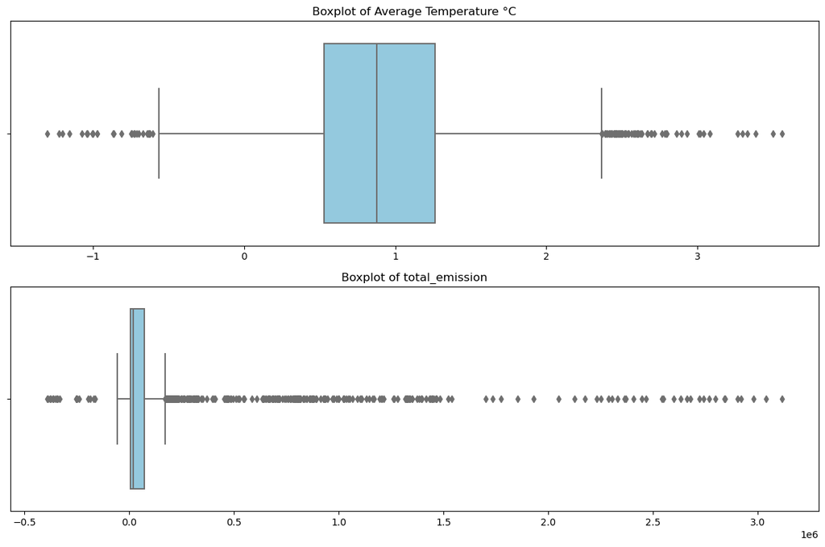

```python
# Boxplot for Average Temperature rise and Total emission
numeric_columns = ['Average Temperature °C', 'total_emission']

import seaborn as sns

# Creating boxplots for each numeric column to visualize outliers
plt.figure(figsize=(12, 8))
for i, column in enumerate(numeric_columns, 1):
    plt.subplot(2, 1, i)
    sns.boxplot(x=df[column], color='skyblue')
    plt.title(f'Boxplot of {column}')
    plt.xlabel('')
plt.tight_layout()
plt.show()
```

Although the boxplot shows multiple records as outliers, we understand that:

- For the Average Temperature rise, a rise between 4 degrees and -2 degrees at max is reasonable.
- As for CO2 emissions, the highest recorded value is approximately 3 million kilotons, originating from China in the year 2020, which is understandable as shown below, (The negative values is because of the carbon sinks from forests overpowering the CO2 emissions).

```python
# Find the index of the row with the maximum total_emission
max_index = df['total_emission'].idxmax()

# Get the entire row corresponding to the maximum total_emission
df.loc[max_index].to_frame().T[['Area', 'Year', 'total_emission']]
```

|  | Area | Year | total_emission |
| --- | --- | --- | --- |
| 911 | China | 2020 | 3115113.7484 |

Overall, we can say that our dataset doesn't have any noticeable outliers.

#### Creating custom columns

**Grouping 19 activities into 5 activities:**

The total CO2 emissions comprises of 19 specific Agri-food activities. It should be noted however that some activities are for similar purposes and perhaps they should be grouped together in order to reach to a more hollistic picture of the situation.

For example,

Grouping variables together on this basis can lead to a clearer understanding of the emissions. Hence, there will be 5 categories: industrial emissions, cultivation emissions, waste disposal emissions, consumption emissions, and fire emissions, as seen bellow.

```python
# Select relevant columns
selected_columns = ['Area', 'total_emission', 'Agrifood Systems Waste Disposal', 'Food Household Consumption',
                    'Forest fires', 'Fires in humid tropical forests', 'Savanna fires',
                    'IPPU', 'Food Processing', 'Food Transport', 'Food Packaging', 'Pesticides Manufacturing',
                    'Fertilizers Manufacturing', 'Food Retail',
                    'Rice Cultivation', 'Manure left on Pasture', 'Drained organic soils (CO2)',
                    'Crop Residues', 'Manure Management', 'Manure applied to Soils', 'Average Temperature °C', 'Year']

# Create a simplified DataFrame with selected columns
simplified_activities = df[selected_columns].copy()

# Calculate the categories total values
emission_sources = ['Forest fires', 'Fires in humid tropical forests', 'Savanna fires',
                    'IPPU', 'Food Processing', 'Food Transport', 'Food Packaging', 'Pesticides Manufacturing',
                    'Fertilizers Manufacturing', 'Food Retail',
                    'Rice Cultivation', 'Manure left on Pasture', 'Drained organic soils (CO2)',
                    'Crop Residues', 'Manure Management', 'Manure applied to Soils']

simplified_activities['total_fire_emissions'] = simplified_activities[emission_sources[:3]].sum(axis=1)
simplified_activities['total_industrial_emissions'] = simplified_activities[emission_sources[3:12]].sum(axis=1)
simplified_activities['total_cultivation_emissions'] = simplified_activities[emission_sources[12:]].sum(axis=1)


# Calculate mean values for all emission sources
simplified_activities_means = simplified_activities[['total_fire_emissions', 'total_industrial_emissions', 'total_cultivation_emissions',
               'Agrifood Systems Waste Disposal', 'Food Household Consumption']].mean()

simplified_activities_means.rename({'total_fire_emissions' : 'mean_fire_emissions', 'total_industrial_emissions' : 'mean_industrial_emissions',
                       'total_cultivation_emissions' : 'mean_cultivation_emissions',
                       'Agrifood Systems Waste Disposal' :  'mean Agrifood Systems Waste Disposal',
                       'Food Household Consumption' : 'mean Food Household Consumption'})


# Sort columns based on mean values in descending order
simplified_activities_means.sort_values(ascending=False, inplace = True)

simplified_activities_cols = simplified_activities_means.index
```

```python
simplified_activities.info()
```

```
<class 'pandas.core.frame.DataFrame'>
RangeIndex: 4577 entries, 0 to 4576
Data columns (total 25 columns):
 #   Column                           Non-Null Count  Dtype
---  ------                           --------------  -----
 0   Area                             4577 non-null   object
 1   total_emission                   4577 non-null   float64
 2   Agrifood Systems Waste Disposal  4577 non-null   float64
 3   Food Household Consumption       4577 non-null   float64
 4   Forest fires                     4577 non-null   float64
 5   Fires in humid tropical forests  4577 non-null   float64
 6   Savanna fires                    4577 non-null   float64
 7   IPPU                             4577 non-null   float64
 8   Food Processing                  4577 non-null   float64
 9   Food Transport                   4577 non-null   float64
```

[output cut: 17 more lines]

Notice the total columns at the end. These will be used in the visualizations later on.

**Grouping countries as regions:**

Since there are too many countries, using them in visualizations can get complex and barely readable. Hence, lets group these nations into regions. I'll use a github file for this grouping (Lukes, 2024).

But first, lets fix some issues in the names of the 'Area' (aka, country) feature.

```python
#Let's fix all the issues with country names
df['Area'].replace({'United States of America': 'United States'}, inplace=True)
df['Area'].replace({'United Kingdom of Great Britain and Northern Ireland': 'United Kingdom'}, inplace=True)
df['Area'].replace({'Democratic Republic of the Congo': 'Congo, The Democratic Republic of the'}, inplace=True)
df['Area'].replace({'Bolivia (Plurinational State of)': 'Bolivia, Plurinational State of'}, inplace=True)
df['Area'].replace({'Venezuela (Bolivarian Republic of)': 'Venezuela, Bolivarian Republic of'}, inplace=True)
df['Area'].replace({'United Republic of Tanzania': 'Tanzania, United Republic of'}, inplace=True)
df['Area'].replace({'Iran (Islamic Republic of)': 'Iran, Islamic Republic of'}, inplace=True)
df['Area'].replace({"Democratic People's Republic of Korea": "Korea, Democratic People's Republic of"}, inplace=True)
df['Area'].replace({"Republic of Korea": "Korea, Republic of"}, inplace=True)
```

```python
# URL of the CSV file which is used to group countries into their respective regions
url = 'https://github.com/lukes/ISO-3166-Countries-with-Regional-Codes/raw/master/all/all.csv'

# Read data from the URL into a DataFrame
regions = pd.read_csv(url)

# Creating a function that takes in the country name and specifies a region for it
def get_region_by_country(country_name):
    # Find the region for the given country name
    try:
        country_region = regions[regions['name'] == country_name]['sub-region'].iloc[0]
        return country_region
    except:
        return None

# Applying the custom function on our Agri-food CO2 emission dataset
df['country_region'] = df['Area'].apply(get_region_by_country)

# Applying the custom function for simplified_activities dataframe as well
simplified_activities['country_region'] = simplified_activities['Area'].apply(get_region_by_country)
```

```python
df.info()
```

```
<class 'pandas.core.frame.DataFrame'>
RangeIndex: 4577 entries, 0 to 4576
Data columns (total 33 columns):
 #   Column                           Non-Null Count  Dtype
---  ------                           --------------  -----
 0   Area                             4577 non-null   object
 1   Year                             4577 non-null   int64
 2   Savanna fires                    4577 non-null   float64
 3   Forest fires                     4577 non-null   float64
 4   Crop Residues                    4577 non-null   float64
 5   Rice Cultivation                 4577 non-null   float64
 6   Drained organic soils (CO2)      4577 non-null   float64
 7   Pesticides Manufacturing         4577 non-null   float64
 8   Food Transport                   4577 non-null   float64
 9   Forestland                       4577 non-null   float64
```

[output cut: 25 more lines]

country_region will be used as a feature in visualization during data exploration.

At this stage, our data is clean and ready for data exploration through visualizations.

**OUR DATA IS CLEAN NOW**

### Data Exploration

Lets understand our dataset through some univariate, bivariate and trivariate visuals.

#### Univariate visualization

**Number of countries per Region:**

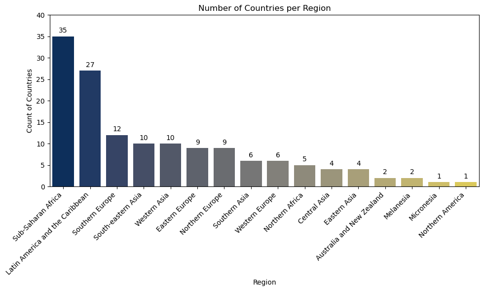

```python
# Group the DataFrame by 'country_region' and count the number of unique values in 'Area' column
region_counts = df.groupby('country_region')['Area'].nunique()

# Sort the data in descending order
region_counts_sorted = region_counts.sort_values(ascending=False)

# Create a gradient color palette
palette = sns.color_palette("cividis", len(region_counts_sorted))

# Create a bar chart using seaborn with gradient colors
plt.figure(figsize=(10, 6))
ax = sns.barplot(x=region_counts_sorted.index, y=region_counts_sorted.values, palette=palette)
plt.title('Number of Countries per Region')
plt.xlabel('Region')
plt.ylabel('Count of Countries')
plt.xticks(rotation=45, ha='right')
plt.ylim(0, max(region_counts_sorted.values) + 5)

# Add data labels
for index, value in enumerate(region_counts_sorted.values):
    ax.text(index, value + 0.5, str(value), ha='center', va='bottom')

plt.tight_layout()
plt.show()
```

This is simply to gain a general understanding of which regions have a high concentration of nations. This assists us in comprehending multivariate plots that utilize regions as a feature for grouping.

**Observations per Year:**

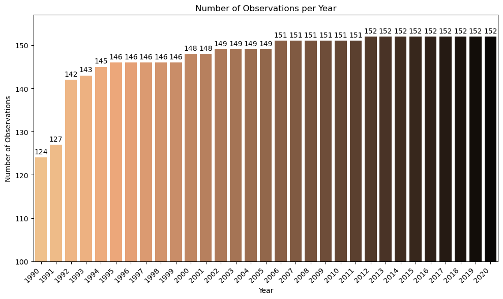

```python
# Count the number of observations per year
year_counts = df['Year'].value_counts().sort_index()

# Create a gradient color palette
palette = sns.color_palette("copper", len(year_counts))
palette = palette[::-1] # reverse order of colour palette

# Create a bar chart using seaborn with gradient colors
plt.figure(figsize=(10, 6))
ax = sns.barplot(x=year_counts.index, y=year_counts.values, palette=palette)
plt.ylim(100, max(year_counts.values) + 5)
plt.title('Number of Observations per Year')
plt.xlabel('Year')
plt.ylabel('Number of Observations')
plt.xticks(rotation=45, ha='right')

# Add data labels
for index, value in enumerate(year_counts.values):
    ax.text(index, value + 0.5, str(value), ha='center', va='bottom')

plt.tight_layout()
plt.show()
```

We observe consistent data recording across the years, with the exception of the initial two years. This is something to bear in mind when utilizing years as a grouping feature or even as a descriptive feature during multivariate visualizations.

**Boxplot & Histogram of Average Temperature Rise:**

We see that the Average Temperature Rise seems to follow a visibly normal distribution. Many Regression models require normality as condition. It is convenient that our target variable is normal and would not require transformation.

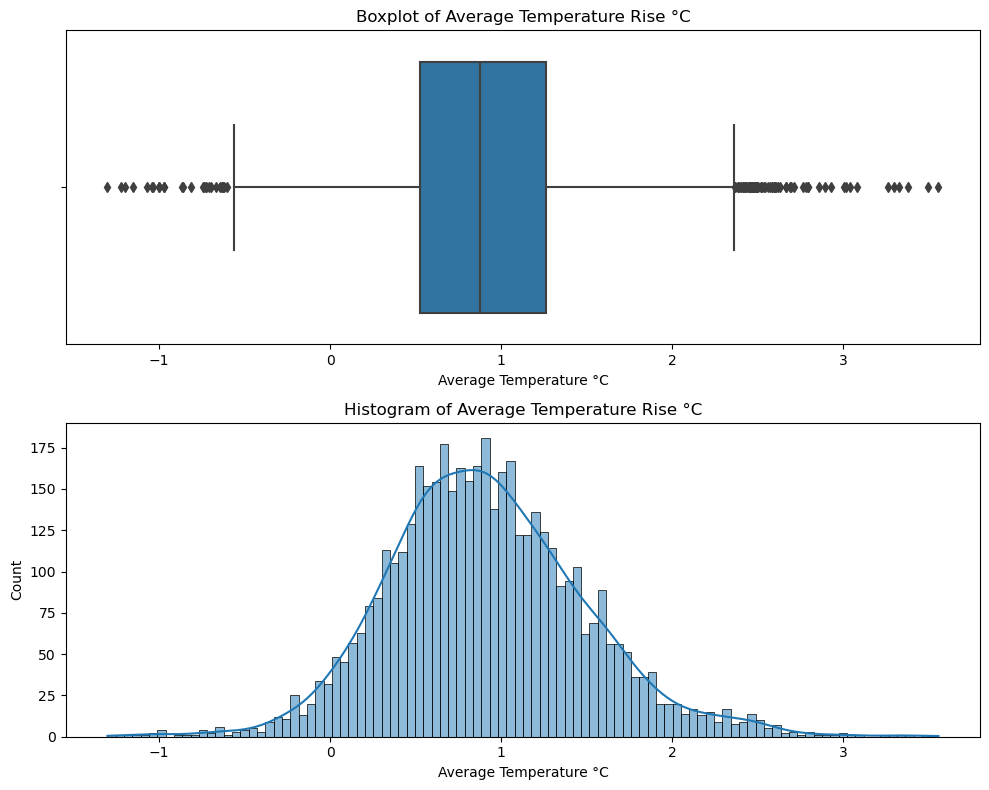

```python
# Set up the figure with subplots
fig, axes = plt.subplots(2, 1, figsize=(10, 8))

# Create a boxplot
sns.boxplot(x=df['Average Temperature °C'], ax=axes[0])
axes[0].set_title('Boxplot of Average Temperature Rise °C')

# Create a histogram
sns.histplot(df['Average Temperature °C'], ax=axes[1], kde=True, bins = 100)
axes[1].set_title('Histogram of Average Temperature Rise °C')

# Adjust layout
plt.tight_layout()

# Show plots
plt.show()
```

**Boxplot & Histogram of Total CO2 Emission:**

Total CO2 emission follows a right skewed distribution. It would require normalization if used as descriptive feature while modeling.

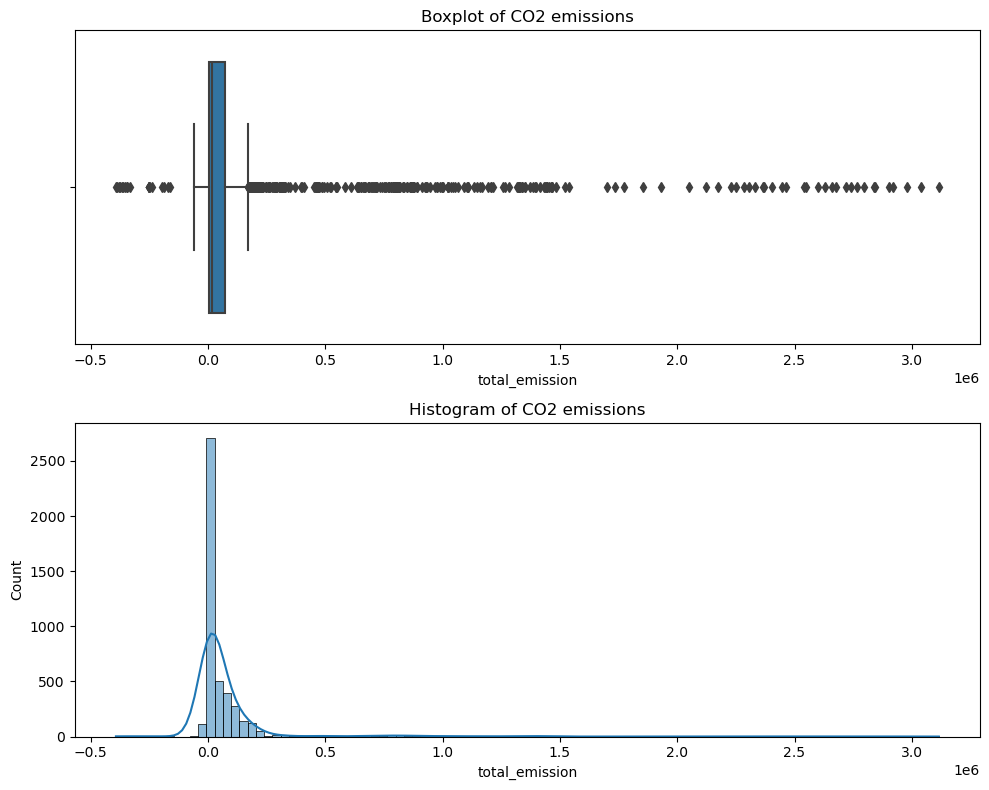

```python
# Set up the figure with subplots
fig, axes = plt.subplots(2, 1, figsize=(10, 8))

# Create a boxplot
sns.boxplot(x=df['total_emission'], ax=axes[0])
axes[0].set_title('Boxplot of CO2 emissions')

# Create a histogram
sns.histplot(df['total_emission'], ax=axes[1], kde=True, bins = 100)
axes[1].set_title('Histogram of CO2 emissions')

# Adjust layout
plt.tight_layout()

# Show plots
plt.show()
```

#### Bivariate Visualisation

**Total CO2 Emission vs Average Temperature Rise:**

Lets plot the absolute CO2 Emissions against the absolute Average Temperature Rise.

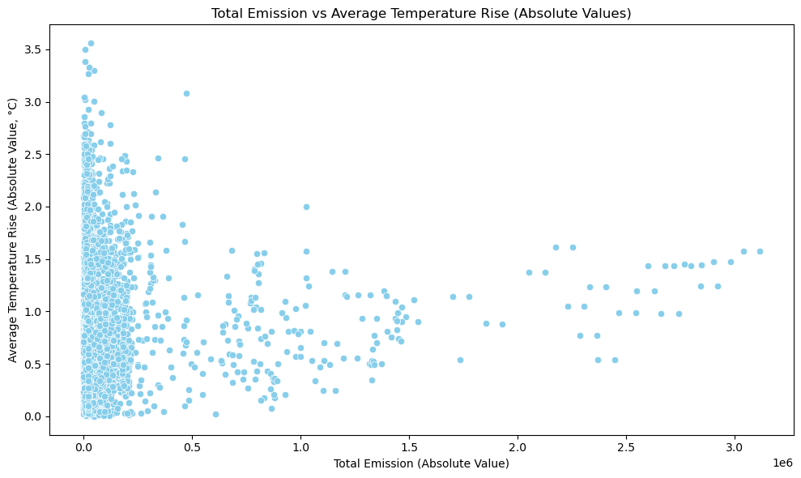

```python
# Create a scatter plot using seaborn using absolute values of 'total_emission' and 'Average Temperature °C'
plt.figure(figsize=(10, 6))
sns.scatterplot(data=df, x=df['total_emission'].abs(), y=df['Average Temperature °C'].abs(), color='skyblue')
plt.title('Total Emission vs Average Temperature Rise (Absolute Values)')
plt.xlabel('Total Emission (Absolute Value)')
plt.ylabel('Average Temperature Rise (Absolute Value, °C)')
plt.tight_layout()
plt.show()
```

If you ignore the cluttering at the 0th point, we do notice some linear correlation between these 2 features when CO2 emissions are not zero. We will again revisit this relation in the Trivariate visualisation where we get rid of the cluttering by using mean values of the CO2 emissions and Temperature rise grouped over the Years.

**Urban population vs Average Temperature Rise:**

Lets plot the Urban Population numbers against the absolute Average Temperature Rise.

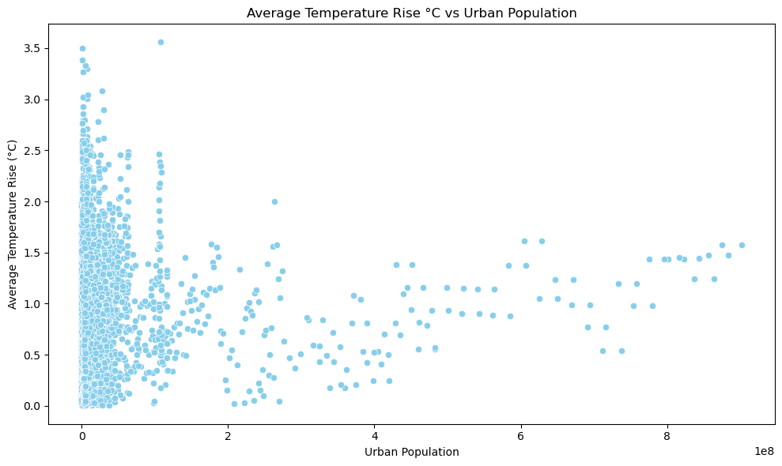

```python
# Create a scatter plot using seaborn
plt.figure(figsize=(10, 6))
sns.scatterplot(data=df, x='Urban population', y=df['Average Temperature °C'].abs(), color='skyblue')
plt.title('Average Temperature Rise °C vs Urban Population')
plt.xlabel('Urban Population')
plt.ylabel('Average Temperature Rise (°C)')
plt.tight_layout()
plt.show()
```

Again, If you ignore the cluttering at the 0th point, we do notice some linear correlation between these 2 features.

**Average CO2 emissions by Agri-food activity:**

The total CO2 emissions comprises of 19 specific Agri-food activities (excluding Forestland which exhibits negative emissions due to its role as a carbon sink). Let's see which activity produces the highest CO2 emissions using the bar chart,

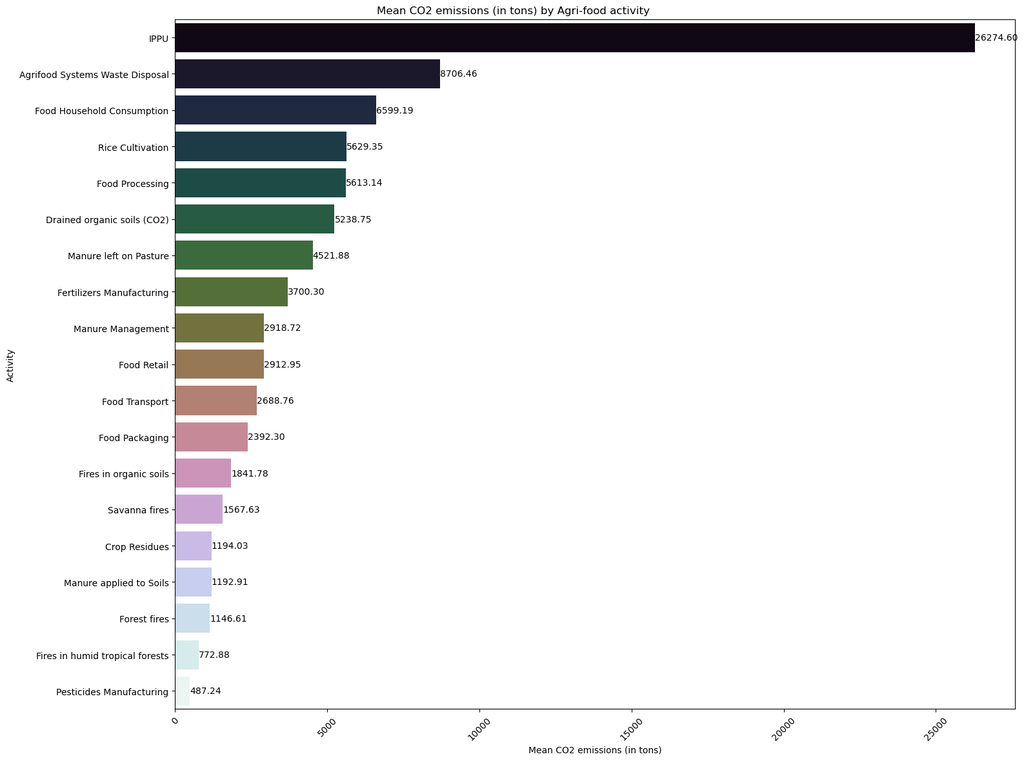

```python
# Select relevant columns and exclude 'delete_list'
Activities = df.iloc[:, 2:-9].copy()
delete_list = ['Forestland', 'Net Forest conversion', 'On-farm Electricity Use']
Activities = Activities.drop(delete_list, axis=1)

# Calculate the mean annual values for each feature
means = Activities.mean()

# Sort the means in descending order
means.sort_values(ascending=False, inplace=True)

# Get the column names as the indices
cols = means.index

# Create the bar plot
fig, ax = plt.subplots(figsize=(16, 12))
sns.barplot(x=means, y=cols, palette="cubehelix", ax=ax)

# Add value labels
for index, value in enumerate(means):
    ax.text(value, index, f'{value:.2f}', ha='left', va='center')

# Set labels and title
ax.set_ylabel("Activity")
ax.set_xlabel("Mean CO2 emissions (in tons)")
fig.suptitle('Mean CO2 emissions (in tons) by Agri-food activity')

plt.xticks(rotation=45)
plt.tight_layout()
plt.show()
```

It is eminent that IPPU is by far the activity with the most CO2 emissions, followed by emissions coming from waste disposal and agrifood products consumption. Thereafter, other industrial and cultivation activities follow, with fire emissions coming towards the end.

Remember, we created simplified_activities dataframe which holds just 5 categories: industrial emissions, cultivation emissions, waste disposal emissions, consumption emissions, and fire emissions. Lets plot the CO2 emissions for these grouped activities,

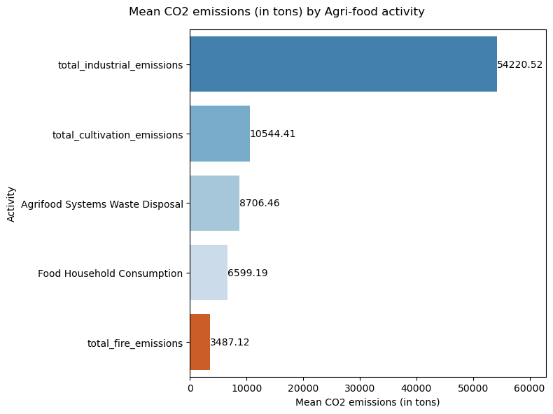

```python
# Create the bar plot with reduced size and "tab10" color palette
fig, ax = plt.subplots(figsize=(8, 6))
sns.barplot(x=simplified_activities_means, y=simplified_activities_cols, palette="tab20c", ax=ax, ci=None, orient='h')

# Add value labels
for index, value in enumerate(simplified_activities_means):
    ax.text(value, index, f'{value:.2f}', ha='left', va='center')

# Set labels and title
ax.set_ylabel("Activity")
ax.set_xlabel("Mean CO2 emissions (in tons)")
fig.suptitle('Mean CO2 emissions (in tons) by Agri-food activity')

# Add space in x-axis
ax.set_xlim(0, simplified_activities_means.max() * 1.16)

plt.tight_layout()
plt.show()
```

**Average Temperature Rise per Region & Total CO2 emission per region:**

Take a look at the CO2 emission and Avg temperature rise variables per region. (NOTE - Consider these as 2 separate bivariate plots. I am putting them side by side for ease of comparison)

```python
simplified_activities.info()
```

```
<class 'pandas.core.frame.DataFrame'>
RangeIndex: 4577 entries, 0 to 4576
Data columns (total 26 columns):
 #   Column                           Non-Null Count  Dtype
---  ------                           --------------  -----
 0   Area                             4577 non-null   object
 1   total_emission                   4577 non-null   float64
 2   Agrifood Systems Waste Disposal  4577 non-null   float64
 3   Food Household Consumption       4577 non-null   float64
 4   Forest fires                     4577 non-null   float64
 5   Fires in humid tropical forests  4577 non-null   float64
 6   Savanna fires                    4577 non-null   float64
 7   IPPU                             4577 non-null   float64
 8   Food Processing                  4577 non-null   float64
 9   Food Transport                   4577 non-null   float64
```

[output cut: 18 more lines]

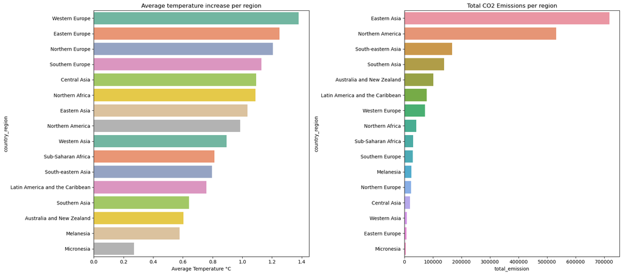

```python
# Create a df with mean Temperature rise and mean total CO2 emission grouped by Region. Set Region as index for visualization
temp3 = simplified_activities[['country_region','Average Temperature °C', 'total_emission']].groupby('country_region').mean()
temp3['country_region'] = temp3.index

fig, axes = plt.subplots(1, 2, figsize=(18, 8))  # Create a grid of 1 row and 2 columns for side-by-side plots

# Plot 1: Average temperature increase per region
temp3.sort_values(by='Average Temperature °C', ascending=False, inplace=True)
sns.barplot(data=temp3, y='country_region', x='Average Temperature °C', ax=axes[0], palette="Set2")
axes[0].set_title('Average temperature increase per region')

# Plot 2: Total CO2 emissions per region
temp3.sort_values(by='total_emission', ascending=False, inplace=True)
sns.barplot(data=temp3, y='country_region', x='total_emission', ax=axes[1])
axes[1].set_title('Total CO2 Emissions per region')

plt.tight_layout()  # Adjust layout to prevent overlap
plt.show()
```

It seems like Europe has sustained the highest temperature increase, while Asia, comes second, even though, Asia has produced the largest CO2 emissions.

#### Trivariate Visualisation

**Total CO2 Emission vs Average Temperature Rise by year:**

Recall, the *"Total CO2 Emission vs Average Temperature Rise"* scatter plot which was cluttered at the 0th point. Lets make that plot readable by getting rid of the cluttering using mean values of the CO2 emissions and Temperature rise grouped over the Years. This should significantly reduce the number of data points, thus uncluttering the 0th point.

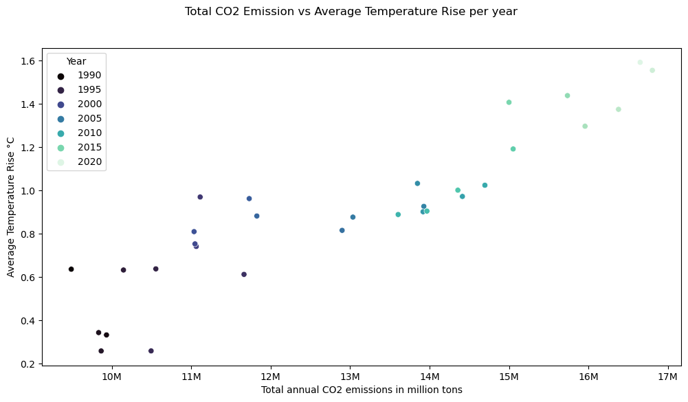

```python
from matplotlib.ticker import FuncFormatter # We use this to convert a big number to millions

#Let's group by year and calculate mean annual temperature and total annual emissions for all countries cummulatively.
temp = df.iloc[:,  1:].groupby('Year').agg({'Average Temperature °C':'mean', 'total_emission':'sum'} )

fig, ax = plt.subplots(figsize = (12, 6))
g = sns.scatterplot(data = temp, x = 'total_emission', y = 'Average Temperature °C', ax = ax, hue ='Year', palette = "mako")

def millions_formatter(x, pos):  # Let's define a function that takes a number divides it by 1000000 and returns it in millions.
    return '{:,.0f}M'.format(x / 1000000)

# Apply the formatter to the x-axis ticks
ax.xaxis.set_major_formatter(FuncFormatter(millions_formatter))

fig.suptitle('Total CO2 Emission vs Average Temperature Rise per year')
ax.set_xlabel('Total annual CO2 emissions in million tons')
ax.set_ylabel('Average Temperature Rise °C')
plt.show()
```

There seems to be a somewhat linear relationship between these two variables. As CO2 emissions increase, average temperature also increases. Additionally, both the CO2 emissions and the average temperature increase through time.

**Total CO2 Emission vs Average Temperature Rise by Region:**

Lets look at the same 2 variables, Total emission and Average Temperature Rise again, but Region wise. See if the regions affect the correlation between the 2 variables,

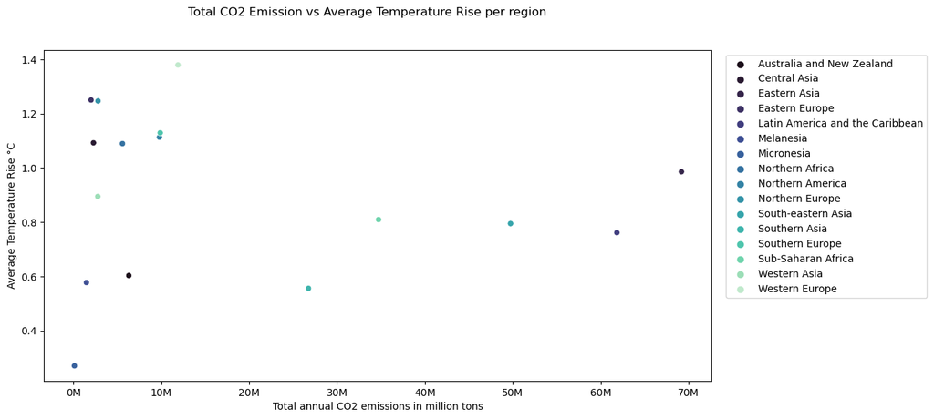

```python
# Let's group by year and calculate mean annual temperature and total annual emissions for all countries cumulatively.
temp = df.iloc[:, 1:].groupby('country_region').agg({'Average Temperature °C':'mean', 'total_emission':'sum'})

fig, ax = plt.subplots(figsize=(12, 6))
g = sns.scatterplot(data=temp, x='total_emission', y='Average Temperature °C', ax=ax, hue='country_region', palette="mako")

def millions_formatter(x, pos):
    return '{:,.0f}M'.format(x / 1000000)

# Apply the formatter to the x-axis ticks
ax.xaxis.set_major_formatter(FuncFormatter(millions_formatter))

fig.suptitle('Total CO2 Emission vs Average Temperature Rise per region')
ax.set_xlabel('Total annual CO2 emissions in million tons')
ax.set_ylabel('Average Temperature Rise °C')

# Move the legend to the upper right corner outside the plot
plt.legend(loc='upper right', bbox_to_anchor=(1.33, 1))
plt.show()
```

The scatter plot depicting the relationship between CO2 emissions and temperature rise per region appears to exhibit a more scattered pattern compared to the relationship per year. This suggests that region may not hold as much significance as year in terms of correlating CO2 emissions with temperature rise.

#### Key Insights and Conclusion

In conclusion, our EDA and visualizations suggest that the target variable, average rise in annual temperature can be well explained by the descriptive features, namely, CO2 emissions all 19 Agri-food activities, Total CO2 emmissions, Urban Population, Year and Region.

#### Future Directions

- Study the impact of remaining features, namely, negative emissions from Forestland, electricty consumption on farms, energy consumption on farms, etc. on target feature, average temperature rise.
- Test regression models or explore other relevant modelling techniques.
- Forecast using the best fitting model (Also impute the missing values using the best fitting model)

#### References

- Alessandro L B (n.d.). Agri-food CO2 emission dataset - Forecasting ML (Kaggle). Retrieved April 24, 2024 from https://www.kaggle.com/datasets/alessandrolobello/agri-food-co2-emission-dataset-forecasting-ml/data
- Lukes (n.d.). lukes/ISO-3166-Countries-with-Regional-Codesps (Github). Retrieved April 24, 2024 from https://github.com/lukes/ISO-3166-Countries-with-Regional-Codes/blob/master/all/all.csvl.csv